# ENES Juriquilla Examen_03

# Estimación e hipótesis, prueba t

## Lic. Tecnología 2023-I

```r
library(tidyverse)
library(rstatix)
```

## Problema 1

¿Podemos concluir que la edad promedio de muerte en los pacientes con drepanocitosis homocigota es menor a los 30 años? Una muestra de 50 pacientes se lista en `EXR_C07_S02_15.csv` con las edades en años, de fallecimiento. Sea alpha = 0.05. Explique qué otras suposiciones fueron necesarias para estimar el resultado. Grafique sus datos y explique su hipótesis y su respuesta.  
Solución:  
El promedio de edad es $ < 30$, entonces la hipótesis nula $H_0 \geq 30$ para que la hipotesis alternativa $H_A < 30$.

```r
# Problema 1
DH_age <- read_csv("~/Dropbox/GitHub/ProbEstad/DataSets/ch07_all/EXR_C07_S02_15.csv", show_col_types = FALSE)
DH_age
```

```
## # A tibble: 50 × 1
##      Age
##    <dbl>
##  1  15.5
##  2   2
##  3  45.1
##  4   1.7
##  5   0.8
##  6   1.1
##  7  18.2
##  8   9.7
##  9  28.1
## 10  18.2
## # … with 40 more rows
```

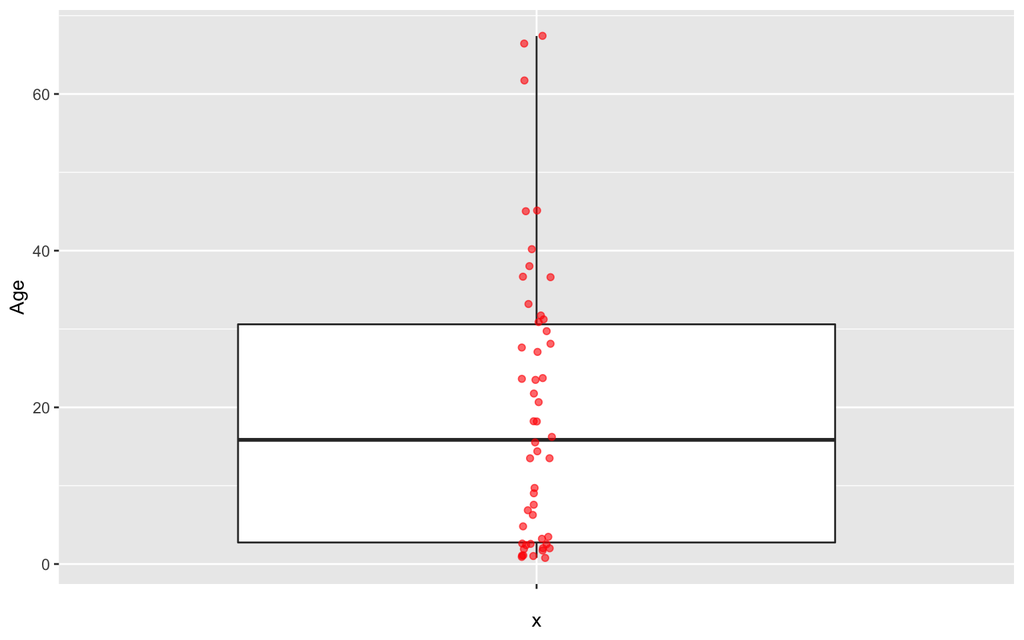

```r
DH_age %>% ggplot(aes(x = '', y = Age)) +
  geom_boxplot() +
  geom_jitter(width = 0.02, alpha = 0.6, color = "red")
```

```r
# pregunta si el promedio de edad es menor a los 30 años.
# suponemos entonces H0 que la edad es mayor a los 30 años y la Ha es que es menor
t.test(DH_age, alternative = "less", mu = 30, paired = FALSE, conf.level = 0.95)
```

```
##
##  One Sample t-test
##
## data:  DH_age
## t = -4.183, df = 49, p-value = 5.933e-05
## alternative hypothesis: true mean is less than 30
## 95 percent confidence interval:
##      -Inf 23.68444
## sample estimates:
## mean of x
##     19.46
```

**Conclusión**: Este nivel de $p$ nos permite tomar la hipótesis alternativa que acepta que el promedio de edad es menor a los 30 años, y es una respuesta significativa.

## Problema 2

¿Podemos concluir que pacientes con hipertensión primaria (PH), en promedio, tienen niveles mayores de colesterol total que los pacientes no hipertensos (NT)? Esta fue una de las preguntas que hizo en su investigación Rossi et al. en la tabla contenida en `EXR_C07_S03_04.csv` se muestran las medidas de colesterol total $(mg/dl)$ de 133 pacientes con PH y 41 pacientes NT. A partir de estos datos ¿se puede concluir que los pacientes PH tienen mayores niveles de colesterol total que los NT? Use $\alpha = 0.05$. Haga gráficas de caja y explique su hipótesis y su respuesta.

Solución  
La hipótesis nula es que los pacientes con $H_0: PH_{col} \leq NT_{col}$ por lo que la hipótesis alternativa es $H_A: PH_{col} > NT_{col}$

```r
# pacientes con PH tienen concentración de colesterol más alta que NT, al 95%
colest <- read_csv("~/Dropbox/GitHub/ProbEstad/DataSets/ch07_all/EXR_C07_S03_04.csv", show_col_types = FALSE)
colest
```

```
## # A tibble: 174 × 2
##    Length Group
##     <dbl> <dbl>
##  1    207     1
##  2    172     1
##  3    191     1
##  4    221     1
##  5    203     1
##  6    241     1
##  7    208     1
##  8    199     1
##  9    185     1
## 10    235     1
## # … with 164 more rows
```

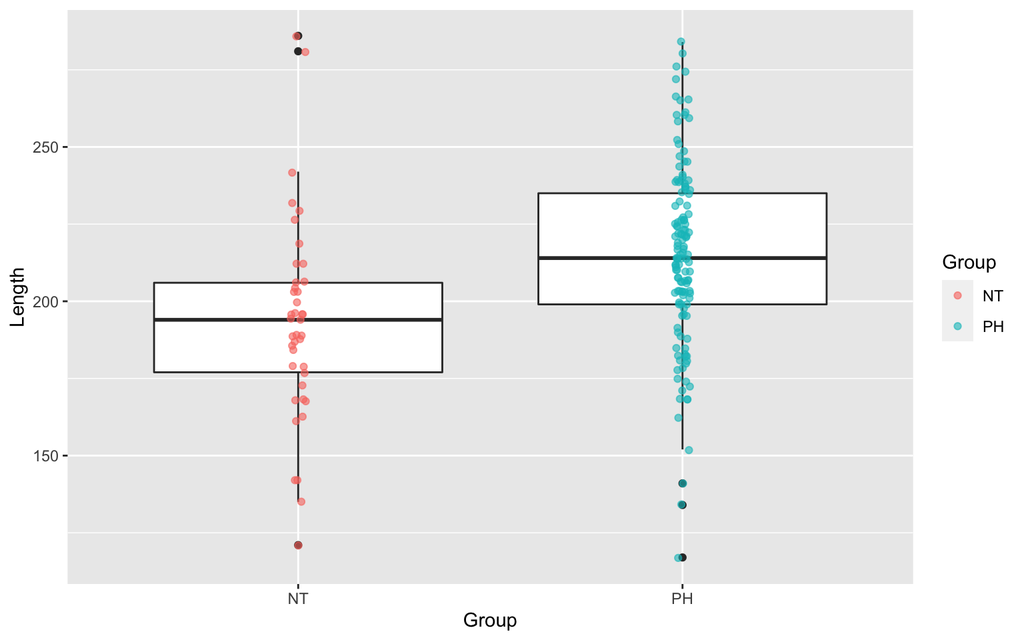

```r
colest_new <- colest %>%
  mutate( Group = case_when (
    Group == 1 ~ "PH",
    Group == 2 ~ "NT" ))

colest_new <- colest_new %>% mutate( Group = Group %>% fct_relevel("NT", "PH"))

# boxplot(Length ~ Group, data = colest_new)
colest_new %>% ggplot(aes(x = Group, y = Length)) +
  geom_boxplot() +
  geom_jitter(width = 0.02, alpha = 0.6, aes(color = Group))
```

```r
t.test(Length ~ Group, paired = FALSE, alternative = "less", data = colest_new)
```

```
##
##  Welch Two Sample t-test
##
## data:  Length by Group
## t = -3.7323, df = 61.178, p-value = 0.0002091
## alternative hypothesis: true difference in means between group NT and group PH is less than 0
## 95 percent confidence interval:
##       -Inf -11.88959
## sample estimates:
## mean in group NT mean in group PH
##         193.1951         214.7143
```

```r
colest_new %>% t_test(Length ~ Group, p.adjust.method = "holm", paired = FALSE, alternative = "less")
```

```
## # A tibble: 1 × 8
##   .y.    group1 group2    n1    n2 statistic    df        p
## * <chr>  <chr>  <chr>  <int> <int>     <dbl> <dbl>    <dbl>
## 1 Length NT     PH        41   133     -3.73  61.2 0.000209
```

**Conclusión**: Se puede concluír que los pacientes normotensos efectivametne tienen menores concetraciones de colesterol en suero.

## Problema 3

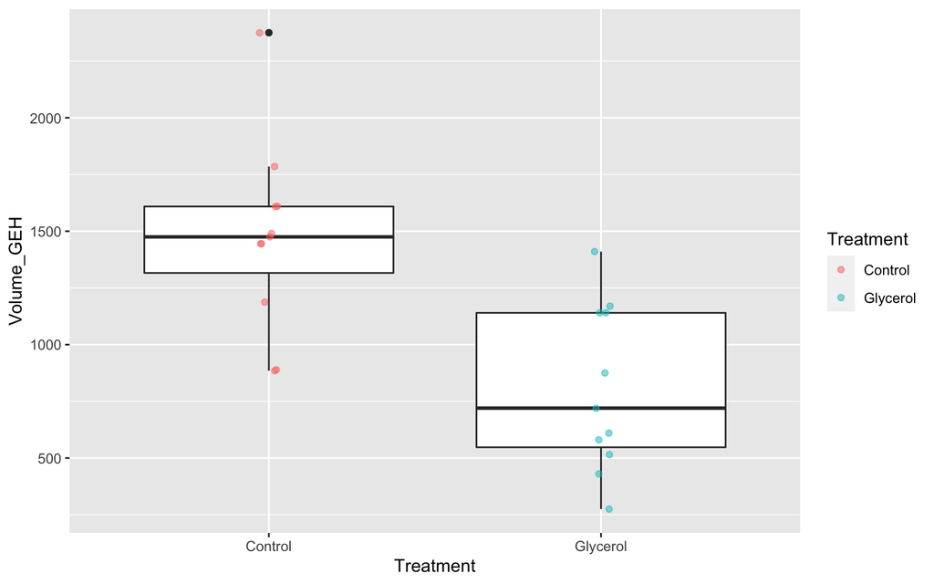

```r
# volúmenes de orina (ml) iniciales seguidos de aquellos con consumo
# de agua con glicerol
GEH <- read_csv("~/Dropbox/GitHub/ProbEstad/DataSets/ch07_all/REV_C07_41.csv", show_col_types = FALSE)

GEH_long <- GEH %>%
  pivot_longer(cols = c("Control", "Glycerol") , names_to = "Treatment", values_to = "Volume_GEH")

GEH_long %>% ggplot(aes(x = Treatment, y = Volume_GEH)) +
  geom_boxplot() +
  geom_jitter(width = 0.03, alpha = 0.5, aes(color = Treatment))
```

```r
# null hypotesis is that the Glycerol treatment results in larger or equal urine volume
t.test(Volume_GEH ~ Treatment, paired = TRUE, alternative = "greater", data = GEH_long)
```

```
##
##  Paired t-test
##
## data:  Volume_GEH by Treatment
## t = 7.0883, df = 10, p-value = 1.671e-05
## alternative hypothesis: true mean difference is greater than 0
## 95 percent confidence interval:
##  495.9772      Inf
## sample estimates:
## mean difference
##        666.3636
```

**Conclusión**: Dado el valor de $p = 0.000$ podemos concluir que la hipótesis alternativa es que los ciclistas en estado *control* (es decir consumo de agua sola) resultla en un volumen de orina mayor, es decir una mayor pérdida de agua.

## Problema 4

Muestras aleatorias simples de dos líneas genéticas de ratones se usaron en un experimento que resultó en las siguientes medidas de niveles de glucosa en suero, después de una experiencia traumática:  
`Línea A: 54, 99, 105, 46, 70, 87, 55, 58, 139, 91`  
`Línea B: 93, 91, 93, 150, 80, 104, 128, 83, 88, 95, 94, 97`  
¿Estos datos dan suficiente evidencia para concluir que la varianza de los datos de los ratones de la línea A es mayor a la varianza de los datos de los ratones de la línea B? Sea $\alpha = 0.05$. Explique su hipótesis nula y todas sus repuestas.  
Respuesta la hipótesis nula es $H_0: \frac{s^2_1}{s^2_2} < 1$ para varianzas diferentes tenemos que aceptar la hipótesis alternativa $H_a: \frac{s^2_1}{s^2_2} \geq 1$  
0

```r
# Usando dos líneas de ratones, se midió niveles de glucosa en suero, después de
# una experiencia traumática

LineA <- c(54, 99, 105, 46, 70, 87, 55, 58, 139, 91)
LineB <- c(93, 91, 93, 150, 80, 104, 128, 83, 88, 95, 94, 97)

var.test(LineA, LineB, ratio = 1, alternative = "greater", conf.level = .95)
```

```
##
##  F test to compare two variances
##
## data:  LineA and LineB
## F = 2.1417, num df = 9, denom df = 11, p-value = 0.1168
## alternative hypothesis: true ratio of variances is greater than 1
## 95 percent confidence interval:
##  0.7394956       Inf
## sample estimates:
## ratio of variances
##           2.141744
```

**Conclusión**: La varianza de la linea A no es mayor que la varianza de la linea B